# 1. Carga y exploración inicial

Fuente de datos, SGCC China:

- Zheng, Z. et al. (2018) Wide and Deep Convolutional Neural Networks for Electricity-Theft Detection to Secure Smart Grids. IEEE transactions on industrial informatics. [Online] 14 (4), 1606–1615.
  - Disponible en *GitHub* (agosto 30, 2018): https://github.com/henryRDlab/ElectricityTheftDetection

```python
import pandas as pd
df = pd.read_csv('data/dataset.csv')
df.head(2)
```

|  | 1/1/2014 | 1/2/2014 | 1/3/2014 | 1/4/2014 | 1/5/2014 | 1/6/2014 | 1/7/2014 | 1/8/2014 | 1/9/2014 | 1/10/2014 | ... | 10/24/2016 | 10/25/2016 | 10/26/2016 | 10/27/2016 | 10/28/2016 | 10/29/2016 | 10/30/2016 | 10/31/2016 | CONS_NO | FLAG |
| --- | --- | --- | --- | --- | --- | --- | --- | --- | --- | --- | --- | --- | --- | --- | --- | --- | --- | --- | --- | --- | --- |
| 0 | 0.0 | 0.0 | 0.01 | 0.0 | 0.0 | 0.0 | 0.0 | 0.0 | 0.0 | 0.0 | ... | 0.02 | 0.06 | 0.58 | 0.89 | 0.35 | 0.38 | 0.70 | 0.25 | 0387DD8A07E07FDA6271170F86AD9151 | 1 |
| 1 | 0.0 | 0.0 | 0.00 | 0.0 | 0.0 | 0.0 | 0.0 | 0.0 | 0.0 | 0.0 | ... | 17.13 | 14.32 | 16.37 | 26.33 | 19.06 | 17.38 | 13.94 | 14.14 | 01D6177B5D4FFE0CABA9EF17DAFC2B84 | 1 |

2 rows × 1036 columns

## 1.1. Estructura y calidad básica

¿La estructura del *dataset* es la esperada?

```python
print("Size ->", df.shape)
dates = list(df.columns[:-2])
dates_sorted  = sorted(dates, key=lambda x: pd.to_datetime(x, format='%m/%d/%Y'))
print("Are columns in chronological order ->", list(dates) == dates_sorted)
print(f"Nº duplicated rows: {df.duplicated().sum()}")

print("\nEvery row is a unique client ->", df['CONS_NO'].nunique() == df.shape[0], "| Then -> ID column deleted")
# CONS_NO (Consumer Number) ya no es útil
df.drop('CONS_NO', axis=1, inplace=True)

print(f"\nNº duplicated rows AFTER client ID drop: {df.duplicated().sum()}")
print("Top 5 highest values of duplicated records")
duplicated_rows = df[df.duplicated(keep=False)].iloc[:, :-1]
max_values = duplicated_rows.max(axis=1).sort_values(ascending=False).head(5)
print(max_values) # No contienen información, se eliminan

df = df.drop_duplicates()
print("New duplicate values removed ->", df.duplicated().sum()==0)
```

```
Size -> (42372, 1036)
Are columns in chronological order -> True
Nº duplicated rows: 0

Every row is a unique client -> True | Then -> ID column deleted

Nº duplicated rows AFTER client ID drop: 873
Top 5 highest values of duplicated records
7464     0.08
5207     0.08
34767    0.01
38487    0.01
575      0.00
dtype: float64
New duplicate values removed -> True
```

**Sí**. Las columnas están ordenadas cronológicamente y cada cliente se representa en una fila única. Cada registro se compone únicamente de fechas con los valores de consumo diarios excepto la última, que es la variable objetivo: `FLAG`.

Se han eliminado registros con exactamente el mismo consumo y tipo de fraude. No aportan nueva información estadística (todos 0s y nulos excepto 4 fechas sobre 1,034 * 873 = 902,682) y se evita *data leakage*.

¿Falta alguna fecha?

```python
date_diffs = pd.to_datetime(df.columns[:-1]).to_series().diff().dt.days
print(date_diffs.value_counts())

first_date = pd.to_datetime(df.columns[0])
last_date = pd.to_datetime(df.columns[-2])
total_days = (last_date - first_date).days

print(f"\nTotal time span: {total_days} days or {total_days / 365:.2f} years")
print(f"First date: {first_date.strftime('%Y-%m-%d')}")
print(f"Last date:  {last_date.strftime('%Y-%m-%d')}")
```

```
1.0    1032
2.0       1
Name: count, dtype: int64

Total time span: 1034 days or 2.83 years
First date: 2014-01-01
Last date:  2016-10-31
```

**Sí**. Con una sola excepción o día faltante, la serie se compone de registros diarios a lo largo de casi 3 años.

## 1.2. Valores inconsistentes

¿Existen valores inconsistentes como *strings* o negativos?

```python
expected_numeric_cols = df.columns[:-1]
non_numeric_cols = [col for col in expected_numeric_cols if not pd.api.types.is_numeric_dtype(df[col])]
print("All columns are numeric ->", len(non_numeric_cols) == 0)
negative_values = (df.iloc[:, :-1] < 0).any().any()
print("Any negative values in the dataset ->", negative_values)
```

```
All columns are numeric -> True
Any negative values in the dataset -> False
```

**No** hay valores inesperados.

## 1.3. Desbalance de clases

```python
print(df['FLAG'].value_counts())
print(df['FLAG'].value_counts(normalize=True))
```

```
FLAG
0    37897
1     3602
Name: count, dtype: int64
FLAG
0    0.913203
1    0.086797
Name: proportion, dtype: float64
```

Se disponen de unas 3,600 muestras fraudulentas, lo que representa un ≈9% del total.

## 1.4. Acercamiento inicial al patrón temporal

Con el fin de identificar las primeras diferencias conductuales entre clientes honestos y fraudulentos, se grafica la evolución de sus consumos promedios y típicos (mediana).

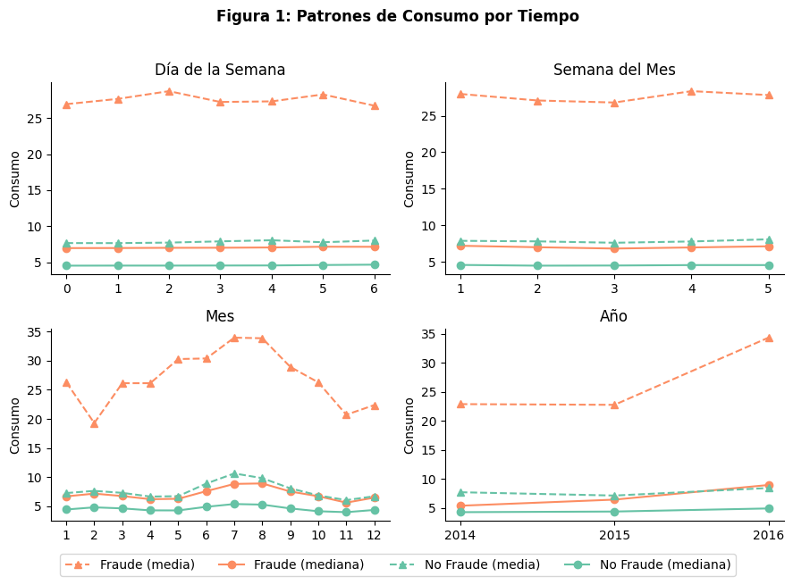

```python
import matplotlib.pyplot as plt
import seaborn as sns

palette = sns.color_palette('Set2', n_colors=2)
df_melted = df.melt(id_vars=['FLAG'], var_name='date_str', value_name='consumption')
df_melted['date'] = pd.to_datetime(df_melted['date_str'], format='%m/%d/%Y')
df_melted['fraud_type'] = df_melted['FLAG'].map({0: 'No Fraude', 1: 'Fraude'})

panels = {
    'Día de la Semana':  (df_melted['date'].dt.dayofweek,             range(7),         None),
    'Semana del Mes':    (((df_melted['date'].dt.day - 1) // 7) + 1,  [1,2,3,4,5],      None),
    'Mes':               (df_melted['date'].dt.month,                 range(1, 13),     None),
    'Año':               (df_melted['date'].dt.year,                  [2014,2015,2016], None),
}

colors    = {'No Fraude': palette[0], 'Fraude': palette[1]}
linestyle = {'mediana': '-', 'media': '--'}
marker    = {'mediana': 'o', 'media': '^'}
stat_map  = {'mean': 'media', 'median': 'mediana'}

fig, axes = plt.subplots(2, 2, figsize=(9, 6))
fig.suptitle('Figura 1: Patrones de Consumo por Tiempo', y=1.02, fontweight='semibold')

for ax, (title, (period, xticks, xticklabels)) in zip(axes.flat, panels.items()):
    df_melted['_period'] = period
    grouped = df_melted.groupby(['_period', 'fraud_type'])['consumption'].agg(['mean', 'median']).reset_index()
    for fraud_type in ['Fraude', 'No Fraude']:
        sub = grouped[grouped['fraud_type'] == fraud_type]
        for stat_en, stat_es in stat_map.items():
            ax.plot(sub['_period'], sub[stat_en],
                    marker=marker[stat_es], linestyle=linestyle[stat_es],
                    color=colors[fraud_type], label=f'{fraud_type} ({stat_es})')
    ax.set_title(title)
    ax.set_ylabel('Consumo')
    ax.set_xticks(xticks)
    if xticklabels:
        ax.set_xticklabels(xticklabels)
    sns.despine(ax=ax)

handles, labels = axes[0, 0].get_legend_handles_labels()
fig.legend(handles, labels, loc='lower center', ncol=4, bbox_to_anchor=(0.5, -0.05))
plt.tight_layout()
plt.show()
```

Viendo que:

- Los clientes que cometen **fraude consumen mucho más**.
- Amplia diferencia entre media y mediana: ***outliers* en ambas clases**.
- La **varianza diaria o semanal es ínfima**.
- **Tendencia anual creciente** compartida, pero más acentuada en fraude.
- Clara **estacionalidad interanual**.
  - En **verano aumenta** el consumo.

# 2. Valores sospechosos de fraude: nulos y ceros

El fraude eléctrico puede revelarse en lecturas modificadas (menores, picos, ceros) o nulas. Este apartado pretende dar respuesta a cuál debe ser el tratamiento de valores cero y nulos en el preprocesamiento conforme a su distribución, impacto y significado.

## 2.1. Distribución e impacto inicial

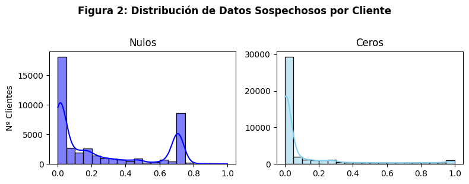

```python
import numpy as np

fig, axes = plt.subplots(1, 2, figsize=(8, 3))
fig.suptitle('Figura 2: Distribución de Datos Sospechosos por Cliente', y=1.02, fontweight='semibold')

# % nulos
null_counts = df.isnull().sum(axis=1)
null_percentages = (null_counts / len(df.columns[:-1]))
sns.histplot(null_percentages, bins=20, kde=True, color='blue', ax=axes[0])
axes[0].set_title('Nulos')
axes[0].set_ylabel('Nº Clientes')

# % 0s
zero_counts = (df.iloc[:, :-1] == 0).sum(axis=1)
zero_percentages = (zero_counts / len(df.columns[:-1]))
sns.histplot(zero_percentages, bins=20, kde=True, color='skyblue', ax=axes[1])
axes[1].set_title('Ceros')
axes[1].set_ylabel(None)

plt.tight_layout()
plt.show()
```

```python
null_rows = df.isnull().any(axis=1)
percentage_null_rows = (null_rows.sum() / len(df)) * 100
print(f"Clients with at least one null value: {percentage_null_rows:.2f}%")
all_null_rows = df.isnull().all(axis=1)
print(f"Clients with all values null: {(all_null_rows.sum() / len(df)) * 100:.2f}%")

zero_rows = (df.iloc[:, :-1] == 0).any(axis=1)
percentage_zero_rows = (zero_rows.sum() / len(df)) * 100
print(f"\nClients with at least one zero value: {percentage_zero_rows:.2f}%")
all_zero_rows = (df.iloc[:, :-1] == 0).all(axis=1)
print(f"Clients with all values zero: {(all_zero_rows.sum() / len(df)) * 100:.2f}%")
```

```
Clients with at least one null value: 100.00%
Clients with all values null: 0.00%

Clients with at least one zero value: 65.04%
Clients with all values zero: 0.00%
```

Notando que:

- Todos los clientes tienen ≥1 nulo.
- Un número importante de clientes tiene un alto porcentaje de nulos (ver *Figura 2* cerca del 70%).
- Un 65% de clientes tiene al menos un valor 0.
- Ningún cliente tiene 100% nulos ni 100% ceros.

## 2.2. Clientes inactivos

¿Hay clientes que no tienen ningún tipo de actividad, es decir, que solo tienen una combinación de nulos y ceros?

```
Nº rows with only nulls and/or 0s: 1243
FLAG
0    1220
1      23
Name: count, dtype: int64
```

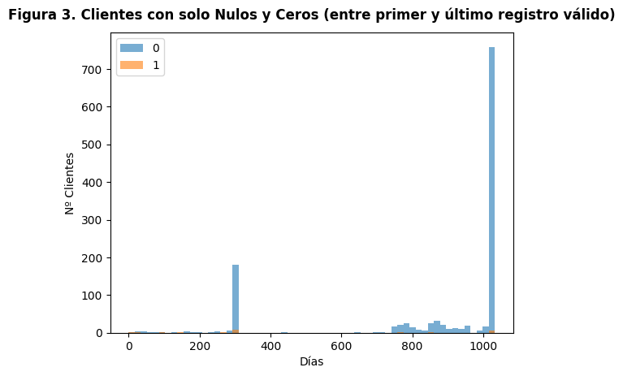

```python
import matplotlib.pyplot as plt

# Filtro de solo nulos y/o ceros
df = df.copy()
null_or_zero_rows = df.iloc[:, :-1].apply(lambda row: (row.isnull() | (row == 0)).all(), axis=1)
print(f"Nº rows with only nulls and/or 0s: {null_or_zero_rows.sum()}")
print(df[null_or_zero_rows]['FLAG'].value_counts())
df_null_zero = df[null_or_zero_rows].reset_index(drop=False).copy()
date_columns = df.columns[:-1]

# Más adelante se verá porque es importante diferenciar entre primer y último no nulo
def sum_days_between_first_and_last_non_null(row):
    non_null_columns = date_columns[row[date_columns].notnull()].tolist()
    if not non_null_columns:
        return 0
    first_col = non_null_columns[0]
    last_col = non_null_columns[-1]
    return df.columns.get_loc(last_col) - df.columns.get_loc(first_col)

# Gráfico
days = df_null_zero.apply(sum_days_between_first_and_last_non_null, axis=1)
df_null_zero = df_null_zero.assign(days_between_first_and_last=days)
df_null_zero.groupby('FLAG')['days_between_first_and_last'].hist(bins=60, alpha=0.6, legend=True, grid=False)
plt.xlabel('Días')
plt.ylabel('Nº Clientes')
plt.title('Figura 3. Clientes con solo Nulos y Ceros (entre primer y último registro válido)', fontweight='semibold', y=1.02)
plt.legend()
plt.show()
```

**Sí**, hay un número considerable de clientes con solo nulos y ceros.

Entendiendo que el primer registro es la fecha de entrada del cliente a la red y el último su salida, se concluye:

- Una fuerte concentración de clientes inactivos no fraudulentos (>700) durante todo el intervalo de observación.
- Muy pocos casos de fraude (23) muestran este comportamiento, distribuyéndose irregularmente en todo el periodo.

Desde una perspectiva real y operativa, es poco probable que se trate de clientes activos (dados de baja, puntos de suministro desactivados, etc.), por lo que no serían auditados. Incluirlos en el proceso de modelización introduciría un patrón predictivo trivial y poco informativo: *Energía total 0 = No fraude*. Aunque esto podría mejorar artificialmente las métricas globales, no mejoraría la capacidad del modelo para distinguir el fraude entre los clientes realmente activos.

Por todo ello, **se prescinde de estos valores**.

```python
df_active_clients = df[~null_or_zero_rows].reset_index(drop=True)
print(f"New size -> {df_active_clients.shape}")
print("New class distribution:\n", df_active_clients['FLAG'].value_counts(normalize=True))
```

```
New size -> (40256, 1035)
New class distribution:
 FLAG
0    0.911094
1    0.088906
Name: proportion, dtype: float64
```

## 2.3. Relación de ausencias con el fraude

Siguiendo el análisis, no es descartable que estos valores sospechosos (ceros y nulos) guarden relación con el fraude. Para profundizar, se desglosa por clase.

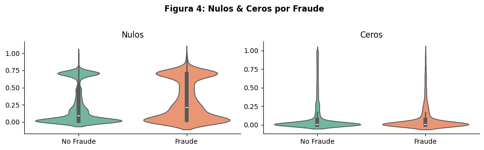

```python
null_percentages_by_flag = df_active_clients.groupby('FLAG').apply(
    lambda x: (x.iloc[:, :-1].isnull().sum(axis=1) / len(x.columns[:-1])),
    include_groups=False
)
plot_data_nulls = null_percentages_by_flag.reset_index()
plot_data_nulls.columns = ['FLAG', 'row_id', 'pct']
plot_data_nulls['FLAG'] = plot_data_nulls['FLAG'].map({0: 'No Fraude', 1: 'Fraude'})

zero_percentages_by_flag = df_active_clients.groupby('FLAG').apply(
    lambda x: (x.iloc[:, :-1].eq(0).sum(axis=1) / len(x.columns[:-1])),
    include_groups=False
)
plot_data_zeros = zero_percentages_by_flag.reset_index()
plot_data_zeros.columns = ['FLAG', 'row_id', 'pct']
plot_data_zeros['FLAG'] = plot_data_zeros['FLAG'].map({0: 'No Fraude', 1: 'Fraude'})

fig, axes = plt.subplots(1, 2, figsize=(10, 3))
fig.suptitle('Figura 4: Nulos & Ceros por Fraude', fontweight='semibold', y=1.02)

sns.violinplot(x='FLAG', y='pct', data=plot_data_nulls,
               palette='Set2', hue='FLAG', ax=axes[0])
axes[0].set_title('Nulos')
axes[0].set_xlabel(None)
axes[0].set_ylabel(None)
sns.despine(ax=axes[0])

sns.violinplot(x='FLAG', y='pct', data=plot_data_zeros,
               palette='Set2', hue='FLAG', ax=axes[1])
axes[1].set_title('Ceros')
axes[1].set_xlabel(None)
axes[1].set_ylabel(None)
sns.despine(ax=axes[1])
plt.tight_layout()
plt.show()
```

Observando que:

- Los **valores ausentes son porcentualmente más frecuentes en clientes que cometen fraude**.
- No ocurre lo mismo con los valores cero.

Véase como se distribuyen estos valores en el tiempo.

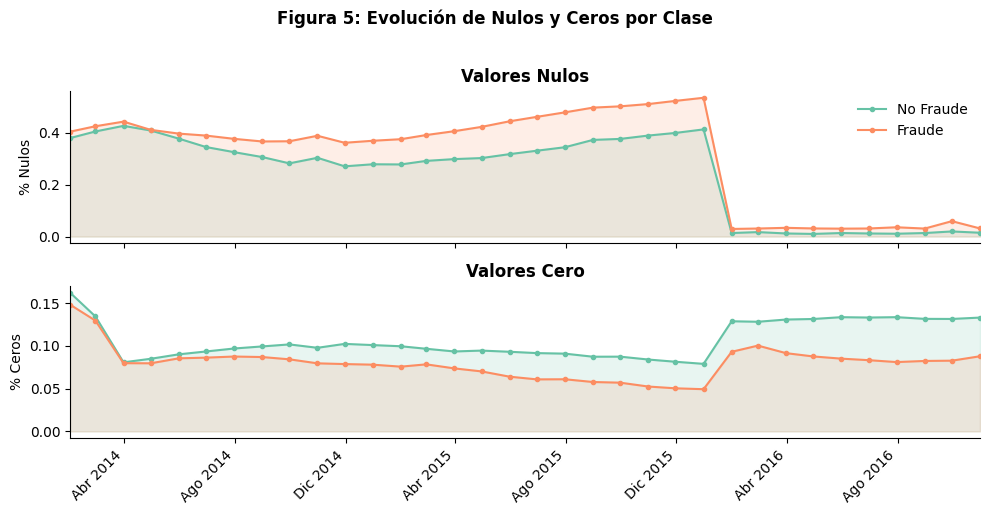

```python
import matplotlib.dates as mdates
import matplotlib.ticker as mticker

date_cols = df_active_clients.columns[:-1]
dates = pd.to_datetime(date_cols, format='%m/%d/%Y')

# Datasets para graficar
null_by_col = pd.DataFrame({
    "date": dates,
    "No Fraude": [df_active_clients.loc[df_active_clients["FLAG"] == 0, col].isnull().mean() for col in date_cols],
    "Fraude":     [df_active_clients.loc[df_active_clients["FLAG"] == 1, col].isnull().mean() for col in date_cols],
})

zero_by_col = pd.DataFrame({
    "date": dates,
    "No Fraude": [df_active_clients.loc[df_active_clients["FLAG"] == 0, col].eq(0).mean() for col in date_cols],
    "Fraude":     [df_active_clients.loc[df_active_clients["FLAG"] == 1, col].eq(0).mean() for col in date_cols],
})

# Medias mensuales
def resample_monthly(df_daily):
    return (df_daily.set_index('date')
                    .resample('ME')
                    .mean()
                    .reset_index())

null_monthly = resample_monthly(null_by_col)
zero_monthly = resample_monthly(zero_by_col)

# Traducción de los meses
MESES_ES = {
    'Jan': 'Ene', 'Feb': 'Feb', 'Mar': 'Mar', 'Apr': 'Abr',
    'May': 'May', 'Jun': 'Jun', 'Jul': 'Jul', 'Aug': 'Ago',
    'Sep': 'Sep', 'Oct': 'Oct', 'Nov': 'Nov', 'Dec': 'Dic'
}

def fmt_fecha_es(x, pos=None):
    dt = mdates.num2date(x)
    mes_en = dt.strftime('%b')
    mes_es = MESES_ES.get(mes_en, mes_en)
    return f"{mes_es} {dt.strftime('%Y')}"

# Plot
def plot_area(ax, data, title, ylabel, legend=False):
    for fraud_type, color in zip(['No Fraude', 'Fraude'], [palette[0], palette[1]]):
        ax.plot(data['date'], data[fraud_type],
                marker='o', markersize=3,
                color=color, linewidth=1.5,
                label=fraud_type)
        ax.fill_between(data['date'], data[fraud_type],
                        alpha=0.15, color=color)
    ax.set_title(title, fontweight='semibold')
    ax.set_ylabel(ylabel)
    ax.set_xlabel(None)
    ax.xaxis.set_major_formatter(mticker.FuncFormatter(fmt_fecha_es))
    ax.xaxis.set_major_locator(mdates.MonthLocator(interval=4))
    ax.set_xlim(data['date'].min(), data['date'].max())
    if legend:
        ax.legend(frameon=False)
    plt.setp(ax.get_xticklabels(), rotation=45, ha='right')
    sns.despine()

fig, axes = plt.subplots(2, 1, figsize=(10, 5), sharex=True)
fig.suptitle('Figura 5: Evolución de Nulos y Ceros por Clase', fontweight='semibold', y=1.02)
plot_area(axes[0], null_monthly, 'Valores Nulos', '% Nulos', legend=True)
plot_area(axes[1], zero_monthly, 'Valores Cero',  '% Ceros')
plt.tight_layout()
plt.show()
```

Estas mediciones no guardan relación con los meses de mayor consumo (verano, ver *figura 1*).

Hay una reducción drástica de los datos nulos en 2016 y un aumento menos drástico de 0s. Esto puede ser causa de un cambio en el sistema de mediciones.

En referencia a los valores 0, un cliente normal puede tener estos consumos de forma esporádica (fines de semana, segundas residencias), mientras, un cliente fraudulento podría registrar varias semanas sin consumo. Para validar esta posibilidad se extrae y analiza la racha máxima de días consecutivos a cero.

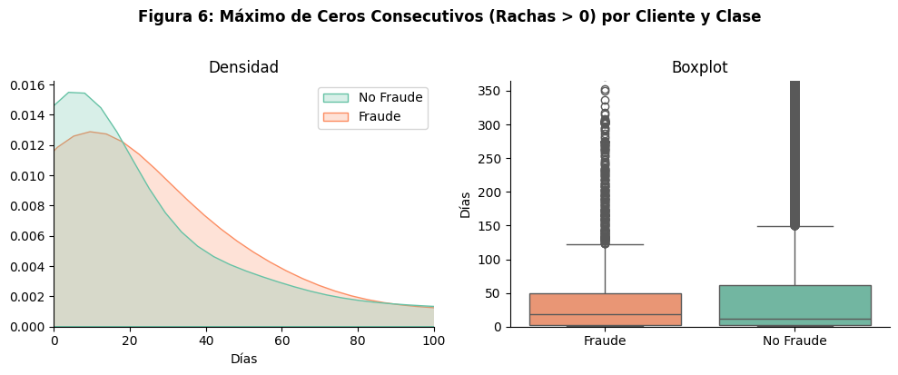

```python
def get_max_zero_streak(row):
    vals = row.iloc[:-1].values
    # Máscara de 0s
    is_zero = (vals == 0) & (~np.isnan(vals))
    if not is_zero.any():
        return 0
    # Se "paddea" como marca de inicio-fin
    padded = np.pad(is_zero, (1, 1), mode='constant')
    # Devuelve el max streak
    edges = np.diff(padded.astype(int))
    starts = np.where(edges == 1)[0]
    ends = np.where(edges == -1)[0]
    return (ends - starts).max()

# Aplicar + gráfico
df_active_clients = df_active_clients.copy()
df_active_clients['max_zero_streak'] = df_active_clients.apply(get_max_zero_streak, axis=1)
df_active_clients['_clase'] = df_active_clients['FLAG'].map({0: 'No Fraude', 1: 'Fraude'})
df_plot = df_active_clients[df_active_clients['max_zero_streak'] > 0]
hue_order = ['No Fraude', 'Fraude']

fig, axes = plt.subplots(1, 2, figsize=(10, 4))
fig.suptitle('Figura 6: Máximo de Ceros Consecutivos (Rachas > 0) por Cliente y Clase',
             fontweight='semibold', y=1.02)
sns.kdeplot(data=df_plot, x='max_zero_streak', hue='_clase', hue_order=hue_order,
            palette='Set2', common_norm=False, fill=True, ax=axes[0])
axes[0].set_title('Densidad')
axes[0].set_xlabel('Días')
axes[0].get_legend().set_title(None)
axes[0].set_ylabel(None)
axes[0].set_xlim(0, 100)
sns.boxplot(data=df_plot, y='max_zero_streak', x='_clase', hue='_clase',
            hue_order=hue_order, palette='Set2', ax=axes[1])
axes[1].set_title('Boxplot')
axes[1].set_ylabel('Días')
axes[1].set_xlabel(None)
axes[1].set_ylim(0, 365)
sns.despine()
plt.tight_layout()
plt.show()

# Se eliminan la columnas tmp
df_active_clients.drop(columns=['max_zero_streak', '_clase'], inplace=True)
```

Viendo que la densidad y la distribución es muy similar para ambos grupos. Alternativamente, si se realiza el mismo gráfico empleando la media de ceros por cliente, se observarán resultados igualmente equivalentes para ambas clases.

Por lo tanto, tras estudiar la relación de los valores 0 con la clase fraudulenta desde varios puntos de vista (inactividad, distribución, evolución, densidad y frecuencia), se determina que esta no tiende a un comportamiento continuo de consumo nulo. Las relaciones simples y directas —como el número de ceros— no parecen guardar información discriminativa para ningún grupo.

Por otro lado, la *Figura 5* ha evidenciado un cambio drástico en la distribución de nulos. ¿Es posible que se hayan añadido muchos clientes al registro al inicio del año 2016?

```python
def count_clients_without_data_before(date_str):
    date_cols_dt = pd.to_datetime(date_cols, format='%m/%d/%Y')
    target_date = pd.to_datetime(date_str, format='%m/%d/%Y')
    cols_before_date = date_cols[date_cols_dt < target_date].tolist()
    clients_without_data = df[cols_before_date].isnull().all(axis=1)
    count = clients_without_data.sum()
    print(f"Nº Clients without any data BEFORE {date_str}:\n{count} -> {count / len(df) * 100:.2f}%\n")

date_to_check1 = '01/01/2016'
date_to_check2 = '01/01/2015'
date_to_check3 = '06/01/2014'

count_clients_without_data_before(date_to_check1)
count_clients_without_data_before(date_to_check2)
count_clients_without_data_before(date_to_check3)
```

```
Nº Clients without any data BEFORE 01/01/2016:
8939 -> 21.54%

Nº Clients without any data BEFORE 01/01/2015:
8971 -> 21.62%

Nº Clients without any data BEFORE 06/01/2014:
12921 -> 31.14%
```

```python
def count_clients_without_data_after(date_str):
    date_cols_dt = pd.to_datetime(date_cols, format='%m/%d/%Y', errors='coerce')
    target_date = pd.to_datetime(date_str, format='%m/%d/%Y')
    cols_after_date = date_cols[date_cols_dt > target_date].tolist()
    clients_without_data = df[cols_after_date].isnull().all(axis=1)
    count = clients_without_data.sum()
    print(f"Nº Clients without any data AFTER {date_str}:\n{count} -> {count / len(df) * 100:.2f}%\n")

date_to_check4 = '9/30/2016' # Penúltimo mes de la serie completa
date_to_check5 = '12/31/2015'
date_to_check6 = '1/1/2014' # Primer día

count_clients_without_data_after(date_to_check4)
count_clients_without_data_after(date_to_check5)
count_clients_without_data_after(date_to_check6)
```

```
Nº Clients without any data AFTER 9/30/2016:
150 -> 0.36%

Nº Clients without any data AFTER 12/31/2015:
42 -> 0.10%

Nº Clients without any data AFTER 1/1/2014:
2 -> 0.00%
```

- **Hallazgo importante**: hay muchos clientes que entraron en el registro más tarde y prácticamente ninguno lo abandonó antes.
- **Significado**: hay diferencias entre nulos de mediciones reales y nulos por inexistencia del registro.
- **Consecuencia**: en *ML* tabular las características deben extraerse sobre el periodo de actividad real del cliente (series recortadas: desde el primer registro no nulo hasta el último).

Además, la función `count_clients_without_data_after` ha demostrado la inexistencia de una regla de negocio tal que: *fraude detectado -> cliente expulsado*. Por lo que se valorará la utilidad de variables de negocio (en *ML* tabular) orientadas al tiempo de vida del cliente o punto de entrada sin riesgo de fuga de datos.

Se presentan estadísticas básicas sobre el tiempo de vida del cliente.

```python
def calculate_lifespan(row):
    # Distancia entre primer y último no nulo
    valid_idx = row.iloc[:-1].first_valid_index()
    last_valid_idx = row.iloc[:-1].last_valid_index()
    if pd.isna(valid_idx) or pd.isna(last_valid_idx):
        return 0
    # En días
    start_date = pd.to_datetime(valid_idx, format='%m/%d/%Y')
    end_date = pd.to_datetime(last_valid_idx, format='%m/%d/%Y')
    return (end_date - start_date).days

lifespans = df_active_clients.apply(calculate_lifespan, axis=1)
lifespans_df = pd.DataFrame({'Lifespan': lifespans, 'FLAG': df_active_clients['FLAG']})
lifespans_df.groupby('FLAG')['Lifespan'].describe()
```

| FLAG | count | mean | std | min | 25% | 50% | 75% | max |
| --- | --- | --- | --- | --- | --- | --- | --- | --- |
| 0 | 36677.0 | 848.413720 | 294.075562 | 3.0 | 789.0 | 1034.0 | 1034.0 | 1034.0 |
| 1 | 3579.0 | 824.814473 | 311.337493 | 4.0 | 484.5 | 1034.0 | 1034.0 | 1034.0 |

Encontrando que la mediana, cuantil 0.75 y máximo son los mismos para ambas clases. No obstante, la distribución es distinta, pues el difiere el cuantil inferior, la desviación típica y la media en menor medida (≈23 días sobre 1,034). Pudiendo resultar en una característica útil pese a una capacidad discriminativa, a priori, potencialmente baja.

## 2.4. Profundización en los nulos reales (*gaps* temporales)

Después del hallazgo anterior, es vital reorientar el estudio hacia los nulos entre datos consistentes (una vez entrados al registro). ¿Son comunes este tipo de nulos intermedios?

```python
def has_intermittent_nulls(row):
    in_non_nulls = False
    for value in row[:-1]:
        if pd.notnull(value):
            in_non_nulls = True
        else:
            if in_non_nulls:
                return True
    return False

mask_intermittent = df_active_clients.apply(has_intermittent_nulls, axis=1)
total = len(df_active_clients)
n_intermittent = mask_intermittent.sum()
print(f"Rows with intermittent nulls: {n_intermittent} / {total} ({n_intermittent / total * 100:.2f}%)")
target_col = df_active_clients.columns[-1]
print("\nBy class:")
for cls in df_active_clients[target_col].unique():
    mask_cls = df_active_clients[target_col] == cls
    n_cls = mask_cls.sum()
    n_cls_intermittent = (mask_intermittent & mask_cls).sum()
    pct = n_cls_intermittent / n_cls * 100
    print(f"  CLASS {cls}: {n_cls_intermittent} / {n_cls} ({pct:.2f}%)")
```

```
Rows with intermittent nulls: 35102 / 40256 (87.20%)

By class:
  CLASS 1: 3140 / 3579 (87.73%)
  CLASS 0: 31962 / 36677 (87.14%)
```

Se aprecia que estos *gaps* aparecen en la mayoría de clientes (87%) independientemente de su clase. Véanse algunas muestras para mayor comprensión.

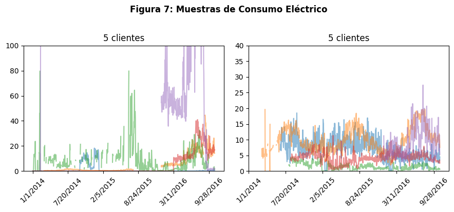

```python
fig, axes = plt.subplots(1, 2, figsize=(9, 4))

for i in range(5):
    axes[0].plot(df_active_clients.columns[:-1], df_active_clients.iloc[i, :-1], alpha=0.5)
axes[0].set_title('5 clientes')
axes[0].set_ylim(0, 100)
axes[0].set_xticks(df_active_clients.columns[::200])
axes[0].tick_params(axis='x', rotation=45)

for i in range(-5, 0):
    axes[1].plot(df_active_clients.columns[:-1], df_active_clients.iloc[i, :-1], alpha=0.5)
axes[1].set_title('5 clientes')
axes[1].set_ylim(0, 40)
axes[1].set_xticks(df_active_clients.columns[::200])
axes[1].tick_params(axis='x', rotation=45)

plt.suptitle('Figura 7: Muestras de Consumo Eléctrico', fontweight='semibold', y=1.02)
plt.tight_layout()
plt.show()
```

Notando que hay clientes con nulos entre fechas muy cercanas.

Sabiendo que el porcentaje de nulos es elevadísimo, es importante reconocer qué datos pueden imputarse y de qué forma. Se tienen en cuenta 2 aspectos fundamentales:

1. Saltos de tiempo largos: si se imputan indiscriminadamente se creará un aprendizaje artificialmente sesgado.
2. Saltos de tiempo cortos: el efecto de la imputación es mínimo y es preferible a perder muchas muestras.

Buscando un equilibrio entre pérdida de información y consistencia, se propone dar respuesta a:

- ¿Cómo se distribuyen los *gaps* máximos por cliente? Que responde a: ¿cuántos se eliminarían con tal umbral?
- ¿Qué tamaños suelen tener?

```python
# Devuelve lista con longitud de cada gap por cliente
def get_internal_gaps(row):
    vals = row.iloc[:-1].values
    # primer y último no nulo
    non_null_idx = np.where(~pd.isna(vals))[0]
    if len(non_null_idx) < 2:
        return []  # excepto si no es posible
    first, last = non_null_idx[0], non_null_idx[-1]
    interior = vals[first:last + 1]
    # Conteo
    gaps = []
    count = 0
    for v in interior:
        if pd.isna(v):
            count += 1
        else:
            if count > 0:
                gaps.append(count)
                count = 0
    return gaps

all_gaps = df_active_clients.apply(get_internal_gaps, axis=1)
max_gaps = all_gaps.apply(lambda gaps: max(gaps) if gaps else 0)
```

```
Initial gap size distribution:
(0.186, 3.71]     0.793749
(3.71, 6.42]      0.099023
(6.42, 9.13]      0.026398
(9.13, 11.84]     0.007860
(11.84, 14.55]    0.009187
(14.55, 17.26]    0.005931
(17.26, 19.97]    0.002679
(19.97, 22.68]    0.003564
(22.68, 25.39]    0.003155
(25.39, 28.1]     0.001828
(28.1, 30.81]     0.000976
(30.81, 33.52]    0.000827
(33.52, 36.23]    0.001015
(36.23, 38.94]    0.000404
(38.94, 41.65]    0.001424
Name: proportion, dtype: float64

Final gap size distribution:
693.0    1
695.0    2
702.0    1
705.0    1
706.0    1
707.0    1
711.0    1
716.0    2
722.0    1
723.0    1
728.0    2
729.0    1
752.0    1
809.0    1
814.0    1
Name: count, dtype: int64
```

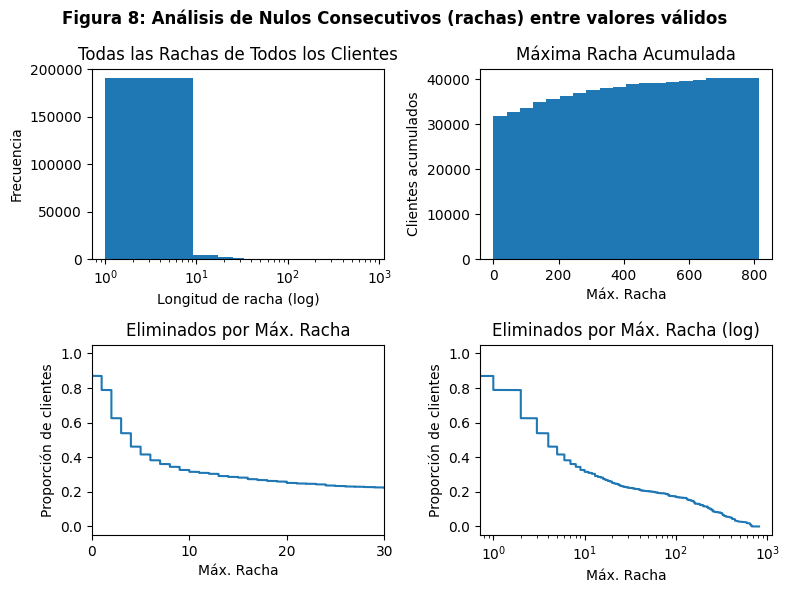

```python
all_gaps_flat = np.concatenate(all_gaps.values)
all_gaps_flat = all_gaps_flat[all_gaps_flat > 0]
print("\nInitial gap size distribution:")
print(pd.Series(all_gaps_flat).value_counts(normalize=True, bins=300).sort_index().head(15))
print("\nFinal gap size distribution:")
print(pd.Series(all_gaps_flat).value_counts().sort_index().tail(15))

vals = np.sort(max_gaps.values)
prop = 1 - np.arange(1, len(vals)+1) / len(vals)

fig, ax = plt.subplots(2, 2, figsize=(8, 6))
ax[0, 0].hist(all_gaps_flat, bins=100)
ax[0, 0].set_xlabel("Longitud de racha (log)")
ax[0, 0].set_ylabel("Frecuencia")
ax[0, 0].set_title("Todas las Rachas de Todos los Clientes")
ax[0, 0].set_xscale('log')

ax[0, 1].hist(max_gaps.values, bins=20, cumulative=True)
ax[0, 1].set_xlabel("Máx. Racha")
ax[0, 1].set_ylabel("Clientes acumulados")
ax[0, 1].set_title("Máxima Racha Acumulada")

ax[1, 0].plot(vals, prop)
ax[1, 0].set_xlabel("Máx. Racha")
ax[1, 0].set_ylabel("Proporción de clientes")
ax[1, 0].set_xticks([0, 10, 20, 30])
ax[1, 0].set_xlim(0, 30)
ax[1, 0].set_title("Eliminados por Máx. Racha")

ax[1, 1].plot(vals, prop)
ax[1, 1].set_xlabel("Máx. Racha")
ax[1, 1].set_ylabel("Proporción de clientes")
ax[1, 1].set_xscale('log')
ax[1, 1].set_title("Eliminados por Máx. Racha (log)")

fig.suptitle("Figura 8: Análisis de Nulos Consecutivos (rachas) entre valores válidos", fontweight='semibold')
plt.tight_layout()
plt.show()
```

Concluyendo:

- Los *gaps* internos son en su inmensa mayoría muy pequeños (casi siempre inferiores a 10).
  - Los *gaps* inferiores a 10 acumulan el ≈92% de los casos.
  - Los *gaps* inferiores a 5 acumulan el ≈85% de los casos.
- Si se eliminan filas por *gap* máximo aceptado, hay poca ganancia acumulada de información después de *max-gap* ≈7.
  - Al poner un umbral de *max-gap* 10 se pierden ~35% de clientes.
  - Los *max-gaps* de varios cientos (en especial > 650) son residuales.

Puesto que cualquier decisión tendrá un fuerte impacto en el número de muestras resultantes se detalla con mayor granularidad.

```python
for x in range(5, 760, 35):
    print(f"Max-gap > {x}: {(max_gaps > x).mean() * 100:.2f}% clients removed")
```

```
Max-gap > 5: 41.65% clients removed
Max-gap > 40: 21.25% clients removed
Max-gap > 75: 19.10% clients removed
Max-gap > 110: 16.74% clients removed
Max-gap > 145: 15.10% clients removed
Max-gap > 180: 13.04% clients removed
Max-gap > 215: 11.55% clients removed
Max-gap > 250: 9.69% clients removed
Max-gap > 285: 8.23% clients removed
Max-gap > 320: 7.55% clients removed
Max-gap > 355: 5.88% clients removed
Max-gap > 390: 5.35% clients removed
Max-gap > 425: 4.37% clients removed
Max-gap > 460: 3.25% clients removed
Max-gap > 495: 2.83% clients removed
Max-gap > 530: 2.66% clients removed
Max-gap > 565: 2.52% clients removed
Max-gap > 600: 1.95% clients removed
Max-gap > 635: 1.87% clients removed
Max-gap > 670: 0.21% clients removed
Max-gap > 705: 0.03% clients removed
Max-gap > 740: 0.01% clients removed
```

```python
def gap_FLAG(df, min_threshold=5, max_threshold=760, step=100):
    thresholds = range(min_threshold, max_threshold + 1, step)
    for x in thresholds:
        mask = max_gaps > x
        if mask.sum() == 0:
            continue
        flag_counts = df.loc[mask, 'FLAG'].value_counts(normalize=True)
        print("=====================================")
        print(f"Max-gap > {x}: {mask.mean() * 100:.2f}% clients removed")
        print(flag_counts)

gap_FLAG(df_active_clients)
```

```
=====================================
Max-gap > 5: 41.65% clients removed
FLAG
0    0.887391
1    0.112609
Name: proportion, dtype: float64
=====================================
Max-gap > 105: 16.95% clients removed
FLAG
0    0.862357
1    0.137643
Name: proportion, dtype: float64
=====================================
Max-gap > 205: 11.60% clients removed
FLAG
0    0.846928
1    0.153072
Name: proportion, dtype: float64
=====================================
Max-gap > 305: 8.06% clients removed
FLAG
0    0.845869
1    0.154131
Name: proportion, dtype: float64
=====================================
Max-gap > 405: 5.15% clients removed
FLAG
0    0.837108
1    0.162892
Name: proportion, dtype: float64
=====================================
Max-gap > 505: 2.77% clients removed
FLAG
0    0.801616
1    0.198384
Name: proportion, dtype: float64
=====================================
Max-gap > 605: 1.94% clients removed
FLAG
0    0.878049
1    0.121951
Name: proportion, dtype: float64
=====================================
Max-gap > 705: 0.03% clients removed
FLAG
1    1.0
Name: proportion, dtype: float64
```

Tras este análisis, se descubre:

- De forma sostenida, los *max-gaps* grandes contienen más fraude porcentual.
- Si se eliminan clientes por *max-gap* superiores a 45 (mes y medio) se pierde el 21% de los datos.

Por tanto,

1. La **eliminación de clientes por *gaps*** pequeños, medianos e incluso bastante grandes, **es insostenible** si se quiere predecir el fraude en los clientes actuales.
2. Hay **indicios** de que los nulos no son una mera consecuencia de errores de medición y pueden esconder información sobre la conducta fraudulenta: *Missing Not At Random* (**MNAR**).

## 2.5. Estrategia final de preprocesamiento de nulos

Conociendo la estructura del *dataset*, no es posible recortar fechas (eliminar columnas), es indispensable aceptar o rechazar toda la serie. Además, se valora la imputación en función del modelaje: *dataset* tabular para *Machine Learning* o serie temporal para *Deep Learning*.

- **Decisiones compartidas (Tabular + Deep Learning)**
  - *Gaps* ≥ 670 se eliminan.
    - Motivo: +670 representan el 0.21% de clientes totales. Son casos muy extremos y residuales, con una estructura temporal prácticamente inexistente, lo que dificulta la extracción de patrones fiables.
- **Dataset Tabular**
  - Se crean variables destinadas a registrar el comportamiento de los nulos (*max_gap*, *null_ratio*, etc.).
    - Motivo: sospecha *MNAR*.
  - *Gaps* ≤ 7 días: se rellenan con interpolación lineal.
    - Motivo: se corrigen +90% de los *gaps* sin introducir señales muy artificiales.
  - *Gaps* > 7 días: se imputan con la mediana mensual del cliente o en su defecto (no dispone) de su global.
    - Motivo: asegura que la imputación de periodos prolongados respete la estacionalidad (reconocidas fluctuaciones en verano) y mantenga los niveles de escala reales del usuario, minimizando la generación de artefactos matemáticos en la posterior extracción de características.
    - Nota: en este grupo hay clientes con series nulas muy prolongadas; se propone la extracción previa de todas aquellas características que sean posibles (ej: media con los datos existentes, luego imputación) para mitigar su impacto.
- **Dataset Deep Learning**
  - No se realizan interpolaciones estructurales largas sobre la serie original.
    - Motivo: se busca preservar la estructura real de ausencia de datos para que el modelo pueda explotar patrones asociados a estos valores.
  - Se crea una máscara binaria asociada a la serie temporal (1 = dato, 0 = nulo).
    - Motivo: permite modelar explícitamente el carácter *MNAR* de los nulos.

```python
def impute_nans(df, max_inner_gap=7):
    # Columnas
    flag_col = df['FLAG']
    df_dates = df.drop(columns=['FLAG']).copy()
    original_cols = df_dates.columns

    # Gaps internos
    has_valid_before = df_dates.notna().cumsum(axis=1) > 0
    has_valid_after = df_dates.iloc[:, ::-1].notna().cumsum(axis=1).iloc[:, ::-1] > 0
    is_internal = has_valid_before & has_valid_after

    # 1. Interpolación lineal (max_inner_gap)
    df_dates = df_dates.interpolate(method='linear', axis=1, limit=max_inner_gap, limit_area='inside')

    # Meses y medianas
    datetime_cols = pd.to_datetime(original_cols)
    global_medians = df_dates.median(axis=1)

    # 2. Imputación por mediana
    for month in range(1, 13):
        month_mask = (datetime_cols.month == month)
        month_cols = original_cols[month_mask]
        # Para cada cliente
        client_monthly_median = df_dates[month_cols].median(axis=1) # Mediana mensual
        client_monthly_median = client_monthly_median.fillna(global_medians) # En su defecto global
        df_dates[month_cols] = df_dates[month_cols].apply(lambda col: col.fillna(client_monthly_median))

    # Reconstrucción dataset
    df_original_dates = df.drop(columns=['FLAG'])
    df_dates = df_dates.where(is_internal, df_original_dates)
    df_final = df_dates.copy()
    df_final['FLAG'] = flag_col

    return df_final

df_no_nulls_active = impute_nans(df_active_clients)
all_gaps = df_no_nulls_active.apply(get_internal_gaps, axis=1)
print(f"Consumers with internal gaps: {(all_gaps.apply(len) > 0).mean() * 100}%")
```

```
Consumers with internal gaps: 0.0%
```

# 3. Clientes inconsistentes

Para crear un sistema de detección de fraude fiable se filtran las muestras extremadamente inconsistentes. Estas se definen como:

- Cliente que en los ≈3 años de registro no tiene 60 días consecutivos.

Un periodo inferior a 2 meses puede ser volátil, sesgado y no representativo, por ejemplo: periodo vacacional, solo periodo de máximo consumo, etc. Igualmente, un registro tan discontinuo puede estar causado por fallos en los aparatos de medición.

A continuación se comprueba cómo esta medida de curación muestral no tiene un impacto relevante en el *dataset*.

```python
def has_x_consecutive_non_nulls(row, x):
    count = 0
    # No se cuenta con la objetivo
    for value in row[:-1]:
        if pd.notnull(value):
            count += 1
            if count >= x:
                return True
        else:
            count = 0
    return False

# Máscara y conteo (conjunto sin imputar)
mask_no60 = ~df_active_clients.apply(has_x_consecutive_non_nulls, axis=1, x=60)
total = len(df_active_clients)
n_no_60 = mask_no60.sum()
print(f"Rows without 60 consecutive non-nulls: {n_no_60} / {total} ({n_no_60 / total * 100:.2f}%)")
df_active_clients_no60 = df_active_clients[~mask_no60].reset_index(drop=True)
print("Shape:", df_active_clients_no60.shape)
```

```
Rows without 60 consecutive non-nulls: 56 / 40256 (0.14%)
Shape: (40200, 1035)
```

# 4. Tratamiento de *outliers*

Aunque el conjunto de datos contiene una única variable explicativa (el consumo eléctrico), la definición de un valor atípico debe ajustarse al objetivo del estudio. En los problemas de detección de fraude, los valores extremos no son necesariamente errores de medición, sino que pueden representar comportamientos anómalos reales.

## 4.1. Análisis de impacto por percentiles (IQR)

Para su detección se proponen tres métricas agregadas de consumo que combinadas tienen en cuenta la afectación de valores nulos:

- **consumo máximo**, para captar picos extremos independientemente de valores faltantes.
- **consumo medio**, para detectar a los clientes con un consumo anormal; métrica donde tienen peso los extremos.
- **consumo total**, otra medida para detectar clientes con consumo extremo (aquí hay más influencia de nulos).

Se propone un enfoque basado en el IQR con diferentes factores para evaluar el potencial impacto de su transformación o eliminación. El siguiente código evalúa cuántas muestras —y en particular, cuántos casos fraudulentos— se eliminarían con diferentes umbrales.

```python
consumption_data = df_active_clients_no60.iloc[:, :-1]

# Métricas
outlier_metrics = pd.DataFrame({
    'total_consumption': consumption_data.sum(axis=1),
    'avg_consumption': consumption_data.mean(axis=1),
    'max_consumption': consumption_data.max(axis=1),
})

def analyze_outliers_impact(df, metrics_df, factor=1.5):
    flags = df.loc[metrics_df.index, 'FLAG']
    total_minority = flags.sum()

    summary = []
    global_outliers = pd.Series(False, index=metrics_df.index)
    # Outliers por métrica
    for col in metrics_df.columns:
        series = metrics_df[col]
        Q1, Q3 = series.quantile(0.25), series.quantile(0.75)
        IQR = Q3 - Q1

        lower_mask = series < (Q1 - factor * IQR)
        upper_mask = series > (Q3 + factor * IQR)
        total_mask = lower_mask | upper_mask

        # Registrar impacto (si alguna métrica es outlier)
        global_outliers |= total_mask
        # De forma individual
        summary.append({
            'Metric': col,
            'Total_Outliers': total_mask.sum(),
            'Lower_Bound': lower_mask.sum(),
            'Upper_Bound': upper_mask.sum(),
            'Minority_Removed (Fraud)': flags[total_mask].sum(),
            '%_Minority_Lost': (flags[total_mask].sum() / total_minority) * 100
        })
    # O en su conjunto (cualquier métrica)
    summary.append({
        'Metric': 'GLOBAL (Any)',
        'Total_Outliers': global_outliers.sum(),
        'Lower_Bound': '-', # Ya registrado individualmente
        'Upper_Bound': '-',
        'Minority_Removed (Fraud)': flags[global_outliers].sum(),
        '%_Minority_Lost': (flags[global_outliers].sum() / total_minority) * 100
    })

    return pd.DataFrame(summary).set_index('Metric')

print("FACTOR:", 1.5)
display(analyze_outliers_impact(df_active_clients_no60, outlier_metrics, factor=1.5))
print("\nFACTOR:", 3)
display(analyze_outliers_impact(df_active_clients_no60, outlier_metrics, factor=3))
print("\nFACTOR:", 10)
display(analyze_outliers_impact(df_active_clients_no60, outlier_metrics, factor=10))
print("\nFACTOR:", 20)
display(analyze_outliers_impact(df_active_clients_no60, outlier_metrics, factor=20))
```

```
FACTOR: 1.5
```

| Metric | Total_Outliers | Lower_Bound | Upper_Bound | Minority_Removed (Fraud) | %_Minority_Lost |
| --- | --- | --- | --- | --- | --- |
| total_consumption | 2135 | 0 | 2135 | 543 | 15.227145 |
| avg_consumption | 2115 | 0 | 2115 | 601 | 16.853617 |
| max_consumption | 2761 | 0 | 2761 | 736 | 20.639372 |
| GLOBAL (Any) | 3922 | - | - | 895 | 25.098149 |

```
FACTOR: 3
```

| Metric | Total_Outliers | Lower_Bound | Upper_Bound | Minority_Removed (Fraud) | %_Minority_Lost |
| --- | --- | --- | --- | --- | --- |
| total_consumption | 969 | 0 | 969 | 322 | 9.029725 |
| avg_consumption | 1013 | 0 | 1013 | 367 | 10.291643 |
| max_consumption | 1595 | 0 | 1595 | 461 | 12.927650 |
| GLOBAL (Any) | 2045 | - | - | 527 | 14.778463 |

```
FACTOR: 10
```

| Metric | Total_Outliers | Lower_Bound | Upper_Bound | Minority_Removed (Fraud) | %_Minority_Lost |
| --- | --- | --- | --- | --- | --- |
| total_consumption | 294 | 0 | 294 | 140 | 3.925967 |
| avg_consumption | 315 | 0 | 315 | 160 | 4.486820 |
| max_consumption | 795 | 0 | 795 | 201 | 5.636568 |
| GLOBAL (Any) | 919 | - | - | 226 | 6.337633 |

```
FACTOR: 20
```

| Metric | Total_Outliers | Lower_Bound | Upper_Bound | Minority_Removed (Fraud) | %_Minority_Lost |
| --- | --- | --- | --- | --- | --- |
| total_consumption | 111 | 0 | 111 | 66 | 1.850813 |
| avg_consumption | 145 | 0 | 145 | 82 | 2.299495 |
| max_consumption | 554 | 0 | 554 | 92 | 2.579921 |
| GLOBAL (Any) | 617 | - | - | 119 | 3.337072 |

Los resultados muestran que eliminar los valores atípicos conduce a una pérdida sustancial de casos fraudulentos. Con un factor IQR estándar de 1.5, se eliminaría casi el 25% de la clase minoritaria. Incluso con umbrales desproporcionadamente altos (factor 10 o 20), se sigue eliminando una proporción significativa de fraude.

Esto indica que el comportamiento de consumo extremo —solo detectado en valores altos— está fuertemente asociado con la actividad fraudulenta. Por lo tanto, estos valores no deben considerarse errores de medición. Más bien, es probable que contengan información discriminatoria.

Por estas razones, **se decide no eliminar ninguna muestra con valores atípicos**. Antes de definir una estrategia concreta se visualiza la distribución de estos valores para mayor contexto.

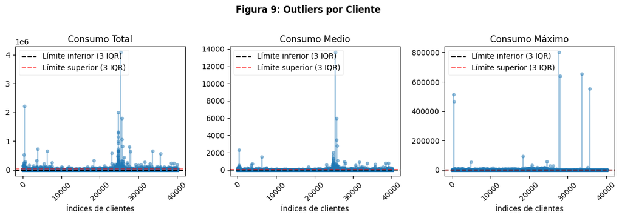

```python
outlier_metrics.rename(columns={
    'total_consumption': 'Consumo Total',
    'avg_consumption': 'Consumo Medio',
    'max_consumption': 'Consumo Máximo'
}, inplace=True)

fig, axes = plt.subplots(1, 3, figsize=(12, 4))
for i, col in enumerate(outlier_metrics.columns):
    axes[i].plot(outlier_metrics[col], marker='o', linestyle='-', markersize=4, alpha=0.4)
    Q1, Q3 = outlier_metrics[col].quantile(0.25), outlier_metrics[col].quantile(0.75)
    IQR = Q3 - Q1
    axes[i].axhline(Q1 - 3 * IQR, color='black', linestyle='--', label='Límite inferior (3 IQR)')
    axes[i].axhline(Q3 + 3 * IQR, color='red', linestyle='--', label='Límite superior (3 IQR)',  alpha=0.5)
    axes[i].set_title(col.replace('_', ' ').title())
    axes[i].set_xlabel('Índices de clientes')
    axes[i].tick_params(axis='x', rotation=45)
    axes[i].legend(loc='upper left', framealpha=0.3)
plt.suptitle('Figura 9: Outliers por Cliente', fontweight='semibold', y=1.02)
plt.tight_layout()
plt.show()
```

Encontrando que muchos clientes se encuentran relativamente cerca del *IQR * 3 (o hasta * 5)*, pero lo más sorprendente son los clientes con consumos desproporcionadamente altos. Se revisan.

## 4.2. Detección de errores por *hardware*

```
FLAG
0    37
1     6
Name: count, dtype: int64
```

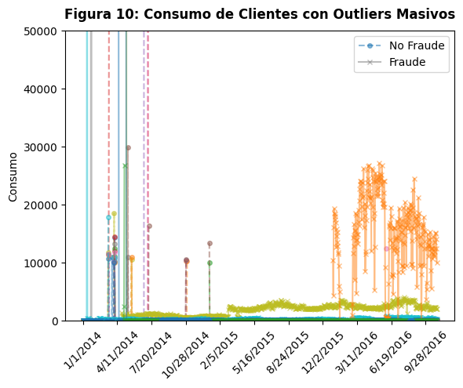

```python
masive_outliers_df = df_active_clients_no60[(consumption_data > 10_000).any(axis=1)]
print(masive_outliers_df['FLAG'].value_counts())

for flag, group in masive_outliers_df.groupby('FLAG'):
    label = 'Fraude' if flag == 1 else 'No Fraude'
    marker = 'x' if flag == 1 else 'o'
    linestyle = '-' if flag == 1 else '--'
    for i in range(len(group)):
        plt.plot(group.columns[:-1], group.iloc[i, :-1],
                 alpha=0.5, marker=marker, markersize=4,
                 linestyle=linestyle, label=label if i == 0 else None)

plt.title('Figura 10: Consumo de Clientes con Outliers Masivos', fontweight='semibold', y=1.02)
plt.ylabel('Consumo')
plt.ylim(0, 50_000)
plt.xticks(df_active_clients_no60.columns[::100], rotation=45)
plt.legend()
plt.show()
```

Esta vez sí, se han reconocido claros errores de medición con independencia de la clase. Para corregirlos se propone:

- **(i) identificar valores por el percentil >0.99,**
- **(ii) que tal valor sea 3 veces su percentil 0.95,**
- **(iii) además debe ser superior a 100,**
- **(iv) sustituirlos por nulos e interpolar linealmente.**

**Justificación**

Aplicar transformaciones como la regla 3σ para delimitar extremos, elimina los valores 0 que pueden tener un significado intrínseco. Además, se ha reconocido un número de valores 0 muy elevado en todas las series, por lo que aplicar transformaciones basadas en la media, elimina de forma drástica esa explosividad que claramente es indicativa de fraude (ver *prints* del apartado 4.1).

Para mantener información relevante sobre los *outliers* se busca una transformación que simplemente elimine los errores puntuales de medición. Al sustituir por nulos e imputar linealmente, se evitan cambios repentinos y drásticos de consumo, respetando los valores locales. Además, se limitan estas identificaciones (*cuantil 0.95 * 3*, *> 100*) para no transformar lecturas reales. Por ejemplo, es posible que un cliente consuma casi siempre 0, pero que aumente mucho el consumo en días puntuales.

```python
def interpolate_spikes(df, extreme_q=0.99, base_q=0.95, multiplier=3, min_absolute=100):
    flag_col = df['FLAG']
    df_dates = df.drop(columns=['FLAG']).copy()
    # Filtro de valores extremos (i)
    q_extreme = df_dates.quantile(extreme_q, axis=1)
    # Umbral percentil base * factor (filtra -> debe ser muy extremo para el cliente (ii))
    q_base = df_dates.quantile(base_q, axis=1)
    scale_threshold = q_base * multiplier
    # Filtro para las 3 condiciones (i, ii, iii)
    final_threshold = np.maximum(q_extreme, scale_threshold)
    final_threshold = np.maximum(final_threshold, min_absolute)
    # Aplica máscara e interpola
    spikes_mask = df_dates.gt(final_threshold, axis=0)
    df_dates = df_dates.mask(spikes_mask, np.nan)
    df_dates = df_dates.interpolate(method='linear', axis=1, limit_area='inside', limit=2)
    # Reconstrucción del dataset
    df_dates['FLAG'] = flag_col
    return df_dates

df_no_spikes_active_no60 = interpolate_spikes(df_active_clients_no60)
masive_outliers_df = df_no_spikes_active_no60[(df_no_spikes_active_no60.iloc[:, :-1] > 10_000).any(axis=1)]
print(masive_outliers_df['FLAG'].value_counts()) # Solo resta el cliente naranja de la Figura 10
```

```
FLAG
1    1
Name: count, dtype: int64
```

El registro del único cliente restante se eliminará por ser un claro error: mal etiquetado, base de datos industrial, medida de medición errónea, etc. Para comprender la dimensión de su consumo, en la siguiente celda se muestra que este consume más que 1,400 clientes aleatorios (sin nulos) en el mismo periodo.

```python
# Primera columna no nula del cliente con consumo masivo
first_non_null_col = masive_outliers_df.iloc[:, :-1].apply(lambda row: row.first_valid_index(), axis=1)

# Se recorta el dataset global a partir de tal fecha y se compara con 1400 clientes sin nulos
start_col = df_no_spikes_active_no60.columns.get_loc(first_non_null_col.iloc[0])
df_trimmed = df_no_spikes_active_no60.iloc[:, start_col:].dropna().sample(n=1400, random_state=42)

# Resultados
sum_trimmed  = df_trimmed.iloc[:, :-1].sum().sum()
sum_outlier = masive_outliers_df.iloc[:, :-1].sum().sum()
print(f"1400 clients:  {sum_trimmed:.2f}")
print(f"Unique client: {sum_outlier:.2f}")

# Se filtra
df_no_spikes_active_no60 = df_no_spikes_active_no60[
    ~(df_no_spikes_active_no60 > 10_000).any(axis=1)
].reset_index(drop=True)
```

```
1400 clients:  4103746.81
Unique client: 4137870.00
```

# 5. Análisis de los componentes

Tras tener los datos mínimamente limpios (aún contienen nulos), se analizan los componentes de la serie temporal.

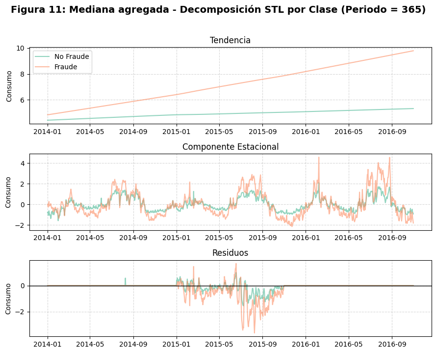

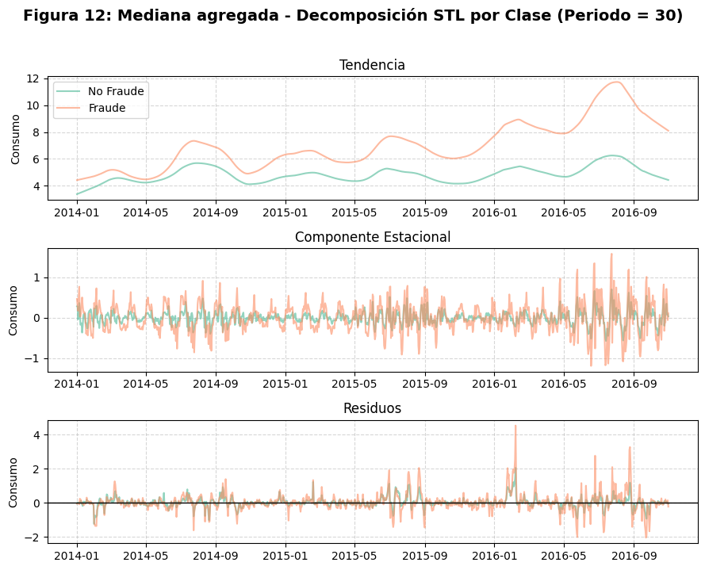

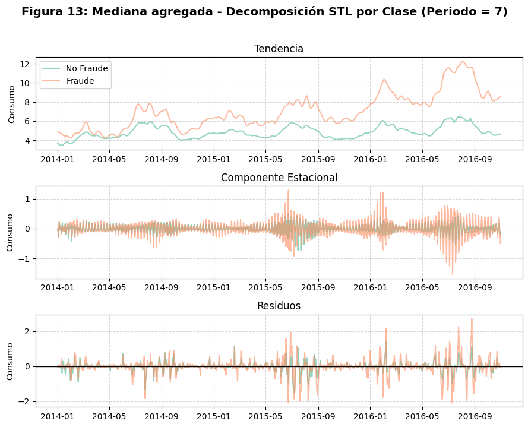

```python
from statsmodels.tsa.seasonal import STL

def plot_macro_stl(df, x_fig, period=365):
    date_cols = [col for col in df.columns if col != 'FLAG']
    # Mediana diaria por clase
    macro_normal = df.loc[df.FLAG==0, date_cols].median()
    macro_fraud  = df.loc[df.FLAG==1, date_cols].median()
    # Fechas
    macro_normal.index = pd.to_datetime(macro_normal.index)
    macro_fraud.index = pd.to_datetime(macro_fraud.index)

    # Decomposición STL
    # period=365 captura estacionalidad anual, 30 mensual, etc;  robust=True mitiga los outliers
    stl_normal = STL(macro_normal, period=period, robust=True).fit()
    stl_fraud = STL(macro_fraud, period=period, robust=True).fit()

    # Plot
    fig, axes = plt.subplots(3, 1, figsize=(9, 7))
    fig.suptitle(f'Figura {x_fig}: Mediana agregada - Decomposición STL por Clase (Periodo = {period})',
                 fontweight='semibold', fontsize=14, y=1.02)

    components = [
        ('Tendencia', stl_normal.trend, stl_fraud.trend),
        ('Componente Estacional', stl_normal.seasonal, stl_fraud.seasonal),
        ('Residuos', stl_normal.resid, stl_fraud.resid)
    ]

    colors = {'No Fraude': palette[0], 'Fraude': palette[1]}

    for i, (title, comp_normal, comp_fraud) in enumerate(components):
        axes[i].plot(comp_normal.index, comp_normal, label='No Fraude',
                     color=colors['No Fraude'], alpha=0.7, linewidth=1.5)
        axes[i].plot(comp_fraud.index, comp_fraud, label='Fraude',
                     color=colors['Fraude'], alpha=0.6, linewidth=1.5)
        axes[i].set_title(title)
        axes[i].set_ylabel('Consumo')
        axes[i].grid(True, linestyle='--', alpha=0.5)
        if i == 0:
            axes[i].legend(loc='upper left')
        # Base de residuos
        elif i == 2:
            axes[i].axhline(0, color='black', linestyle='-', linewidth=1)
    plt.tight_layout()
    plt.show()

plot_macro_stl(df_no_spikes_active_no60, x_fig=11, period=365)
plot_macro_stl(df_no_spikes_active_no60, x_fig=12, period=30)
plot_macro_stl(df_no_spikes_active_no60, x_fig=13, period=7)
```

- Componente de tendencia

En la escala *p=365*, el perfil sin fraude muestra un consumo base bajo (~4), notablemente estable y ligeramente creciente. Por el contrario, el perfil con fraude ya arranca con un consumo superior y exhibe una tendencia mucho más creciente. En las descomposiciones de periodo menor (*p=30* y *p=7*), la tendencia absorbe los ciclos anuales. En estas, se observa que el fraude es más ondulante y susceptible a los cambios de temporada en comparación con un cliente normal.

- Componente estacional

En el patrón anual, ambos grupos responden a estacionalidades anuales pero el grupo de fraude lo hace con valles más profundos y picos más altos. En los periodos semanales y mensuales, el consumo normal muestra pequeños ciclos ajustados al periodo de forma regular y con muy baja amplitud (cercanos a 0). Mientras, el fraude es menos regular y mucho más volátil. Es muy llamativo el gráfico de *p=7* a mediados de 2015, donde los clientes fraudulentos típicos tienen oscilaciones violentas cada vez más amplias; concluyendo que pierde la regularidad en los hábitos de consumo a corto plazo.

- Ruido

El ruido en los clientes sin fraude es mínimo, normalmente constante y cercano al cero. Por lo tanto, su comportamiento es relativamente predecible (explicable) a partir de la tendencia y estacionalidad. En contrapartida, el fraude sí tiene una varianza notablemente mayor y más alejada del 0. Estos cambios abruptos y comúnmente negativos sugieren que ocurren anomalías independientes al calendario. Siendo compatible con manipulaciones del contador, desconexiones temporales, lecturas alteradas, etc.

**Consecuencias**

Conforme al análisis se concluyen distintas características a extraer para los modelos tabulares:

1. Pendiente de la regresión lineal: para capturar el tipo de crecimiento a largo plazo.
2. Percentiles altos, media y mediana: dado que las líneas base de consumo son notoriamente distintas.
3. Desviación estándar y rango intercuartílico (IQR): para registrar la dispersión.
4. Energía de la serie (suma de los cuadrados) y suma de valores absolutos de las diferencias consecutivas: para detectar a los perfiles con saltos diarios constantes (ver *p=7*).
5. Transformada de Fourier (FFT): para comparar la estacionalidad periódica (alterada o magnificada en fraude).
6. Asimetría: facilita la identificación de series con muchos valores muy bajos o muy altos, sobre todo, por la importancia de los residuos muy negativos y la tendencia creciente.
7. Número de caídas bruscas: contar cuántas veces el consumo cae más de un x% de un día para otro.
8. Entropía: puesto que no debería ser muy elevada en consumos corrientes.

# 6. Autocorrelación y estacionariedad

Tras analizar los componentes, es pertinente estudiar la autocorrelación estructural de las series. A priori, un consumo eléctrico normal debería estar correlacionado con sus retardos (*lags*) recientes. Por ejemplo, el consumo de un día debería ser similar al de hace 1 semana. Para medirlo se usa la Función de Autocorrelación (*ACF*).

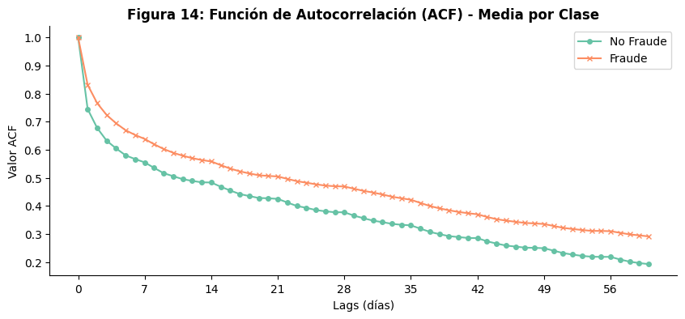

```python
from statsmodels.tsa.stattools import acf

def get_mean_acf(df, lags, sample_size=2_000):
    # Nota: sample_size máximo para la clase fraude es ~3000
    sample_df = df.sample(n=sample_size, random_state=42)
    acf_values = []
    for _, row in sample_df.iterrows():
        # Obligatorio interpolar
        series = row.iloc[:-1].astype(float).interpolate(method='linear', limit_direction='both')
        # Se extraen los coeficientes de autocorrelación
        acf_val = acf(series, nlags=lags, fft=True)
        acf_values.append(acf_val)
    return np.mean(acf_values, axis=0)

# Se usa el dataset más limpio
fraud_df = df_no_spikes_active_no60[df_no_spikes_active_no60['FLAG'] == 1]
normal_df = df_no_spikes_active_no60[df_no_spikes_active_no60['FLAG'] == 0]
# Se calculan hasta 60 lags
lags = 60
acf_fraud = get_mean_acf(fraud_df, lags=lags)
acf_normal = get_mean_acf(normal_df, lags=lags)
# Plot
plt.figure(figsize=(10, 4))
plt.plot(range(lags+1), acf_normal, marker='o', markersize=4,
            label='No Fraude', color=palette[0])
plt.plot(range(lags+1), acf_fraud, marker='x', markersize=4,
            label='Fraude', color=palette[1])
plt.title('Figura 14: Función de Autocorrelación (ACF) - Media por Clase', fontweight='semibold')
plt.xlabel('Lags (días)')
plt.ylabel('Valor ACF')
plt.xticks(range(0, lags+1, 7))
plt.legend()
sns.despine()
plt.show()
```

El vector promedio de autocorrelaciones para 2,000 muestras indica que ambas clases tienen una dependencia temporal positiva incluso con un retardo de 60 días (llega 0 sobre los 90, ampliar `lags` para ver). Estos valores son ligera y sorprendentemente más altos para las series fraudulentas, sugiriendo una mayor persistencia temporal. La diferencia entre ambas clases se sostiene a lo largo del tiempo, pero diverge desde los primeros valores.

Para un mayor detalle y confirmación estadística se comprueba si la hipótesis de que las series son estacionarias, es decir, que sus propiedades no cambian con el tiempo, se cumplen para ambas clases. Para ello, se emplea el test Dickey-Fuller aumentado (ver: [adfuller](https://www.statsmodels.org/dev/examples/notebooks/generated/stationarity_detrending_adf_kpss.html#ADF-test)).

```python
from statsmodels.tsa.stattools import adfuller

def check_stationarity_ratio(df, sample_size=1_000):
    # No se recomienda subir sample_size, cálculo pesado
    sample_df = df.sample(n=sample_size, random_state=42)
    stationary_count = 0
    for _, row in sample_df.iterrows():
        # De nuevo, obligatorio interpolar
        series = row.iloc[:-1].astype(float).interpolate(method='linear').bfill().ffill()
        # Test ADF
        try:
            result = adfuller(series.values)
            p_value = result[1]
            # Si p-value < 0.05, es estacionaria
            if p_value < 0.05:
                stationary_count += 1
        except:
            continue

    return (stationary_count / sample_size) * 100

stat_ratio_fraud = check_stationarity_ratio(fraud_df)
stat_ratio_normal = check_stationarity_ratio(normal_df)

print(f"Stationary Series (No Fraud): {stat_ratio_normal:.2f}%")
print(f"Stationary Series (Fraud):    {stat_ratio_fraud:.2f}%")
```

```
Stationary Series (No Fraud): 61.20%
Stationary Series (Fraud):    48.70%
```

Aproximadamente el 61% de las series no fraudulentas pueden considerarse estacionarias, frente a un 49% en el caso contrario. Esto sugiere que los segundos tienen consumos inestables o cambios estructurales a largo plazo. No obstante, la diferencia entre ambas clases no es extrema, por lo que la estacionariedad por sí sola puede no ser un factor discriminante fuerte.

En suma, los valores *ACF* indican que el fraude mantiene cierta dependencia temporal local, pero al mismo tiempo (ver *STL* y *ADF*) tienen desniveles en el consumo o patrones irregulares que rompen la estacionariedad global.

# 7. Breve análisis bivariante

Previo a la extracción masiva de características, resulta útil confirmar si algunas estadísticas extremadamente simples (media, varianza) ya ofrecen algún grado de separabilidad lineal o evidencian multicolinealidad entre ambas clases. Se crea una pequeña prueba bivariante para proyectar la complejidad de la extracción.

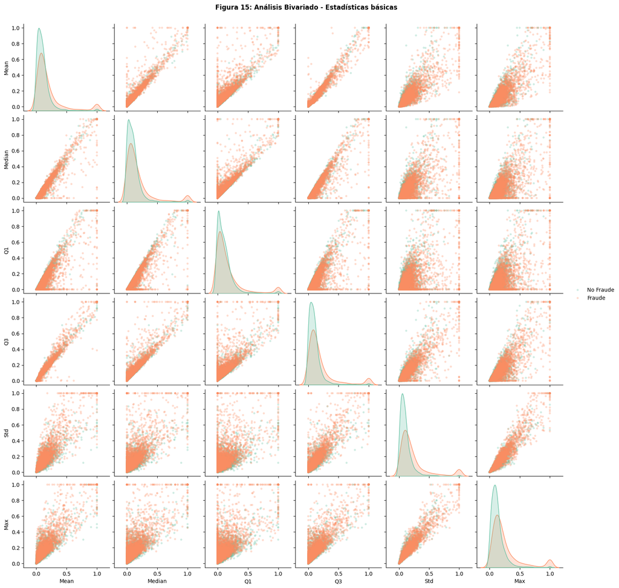

```python
from sklearn.preprocessing import MinMaxScaler

df_test = pd.DataFrame()
ts_data = df_no_spikes_active_no60.iloc[:, :-1]

df_test['Mean'] = ts_data.mean(axis=1)
df_test['Median'] = ts_data.median(axis=1)
df_test['Q1'] = ts_data.quantile(0.25, axis=1)
df_test['Q3'] = ts_data.quantile(0.75, axis=1)
df_test['Std'] = ts_data.std(axis=1)
df_test['Max'] = ts_data.max(axis=1)
df_test['FLAG'] = df_no_spikes_active_no60['FLAG'].map({0: 'No Fraude', 1: 'Fraude'})
df_test['FLAG'] = pd.Categorical(df_test['FLAG'], categories=['No Fraude', 'Fraude'])

# Escalado (clipping + MinMaxScaler) para mejor visualización
def clipping_and_scaling(df, features, scaler):
    for col in features:
        df[col] = df[col].clip(
            df[col].quantile(0.01),
            df[col].quantile(0.99)
        )
    return scaler.fit_transform(df[features])
scaler = MinMaxScaler()
features = df_test.drop("FLAG", axis=1).columns
df_test[features] = clipping_and_scaling(df_test, features, scaler)

# Submuestro y plot
df_test_sample = df_test.groupby('FLAG').sample(n=3_000, random_state=42)
pp = sns.pairplot(df_test_sample, hue='FLAG', palette='Set2',
                    plot_kws={'alpha': 0.3, 's': 15, 'linewidth': 0},
                    diag_kind='kde')
pp._legend.set_title(None)
pp.figure.suptitle('Figura 15: Análisis Bivariado - Estadísticas básicas',
                y=1.02, fontweight='semibold')
plt.show()
```

Las distribuciones diagonales muestran que ambas clases se solapan considerablemente en todas las *features*. Sin embargo, de forma consistente el fraude (naranja) presenta valores más altos en todas las métricas, con colas largas hacia la derecha, mientras que el no fraude (verde) tiene distribuciones con picos más altos (más concentradas). Esto sugiere que existe separabilidad, pero no es lineal ni perfecta, por lo que ninguna *feature* por sí sola discriminará entre clases.

Seguidamente, los *scatterplots* hacen evidente la multicolinealidad con sus patrones diagonales. Siendo `Std` la que tiene un comportamiento linealmente más independiente. El resto pueden aportar información redundante y dificultar la interpretabilidad.

Concluyendo, la extracción masiva de características parece necesaria para capturar patrones más complejos. Lo que requiere aplicar una reducción de dimensionalidad o selección de variables, un paso que también mitigará la más que posible multicolinealidad. Viendo las colas largas de fraude, cálculos como *skewness*, *kurtosis* o percentiles extremos podrían añadir cierto valor discriminativo.

# 8. Patrones de consumo (*clustering*)

Se propone una clusterización mediante *KMeans* para poder identificar los distintos patrones de consumo y revelar qué define estadísticamente al grupo fraudulento.

```python
from sklearn.cluster import KMeans
from sklearn.preprocessing import StandardScaler

df_test = pd.DataFrame()
ts_data = df_no_spikes_active_no60.iloc[:, :-1]

# features básicas
df_test["mean"] = ts_data.mean(axis=1)
df_test["std"] = ts_data.std(axis=1)
df_test["coef_var"] = df_test["std"] / (df_test["mean"] + 1)
df_test["p10"] = ts_data.quantile(0.10, axis=1)
df_test["p50"] = ts_data.quantile(0.50, axis=1)
df_test["p95"] = ts_data.quantile(0.95, axis=1)
eps = 1
df_test["peak_ratio"] = df_test["p95"] / (df_test["p50"] + eps)
df_test["drop_ratio"] = df_test["p10"] / (df_test["p50"] + eps)
df_test["FLAG"] = df_no_spikes_active_no60["FLAG"]

# Se escala para mitigar outliers y diferencias de escala
scaler = StandardScaler()
features = df_test.drop("FLAG", axis=1)
features_scaled = clipping_and_scaling(df_test, features.columns, scaler)

######
## Selección de k -> entre 2 y 4 es un valor razonable
# inertia = []
# k_values = range(2, 10)
# for k in k_values:
#     kmeans = KMeans(n_clusters=k, random_state=42, n_init=10)
#     kmeans.fit(features_scaled)
#     inertia.append(kmeans.inertia_)
# print("Inertia values for k:")
# for k, inertia_value in zip(k_values, inertia):
#     print(f"k = {k} | Inertia = {inertia_value:.2f}")
#######

# Clustering
kmeans = KMeans(n_clusters=4, random_state=42)
clusters = kmeans.fit_predict(features_scaled)
df_test.loc[:, "Cluster"] = clusters
print(df_test.value_counts('Cluster'))
cluster_summary = df_test.groupby("Cluster").mean()
cluster_summary
```

```
Cluster
0    18228
2    15840
3     5330
1      801
Name: count, dtype: int64
```

| Cluster | mean | std | coef_var | p10 | p50 | p95 | peak_ratio | drop_ratio | FLAG |
| --- | --- | --- | --- | --- | --- | --- | --- | --- | --- |
| 0 | 6.942817 | 3.087184 | 0.373007 | 3.870324 | 6.325296 | 12.757604 | 1.686968 | 0.503741 | 0.056945 |
| 1 | 63.939916 | 32.647103 | 0.556419 | 22.330017 | 54.691949 | 124.332441 | 2.931740 | 0.443967 | 0.394507 |
| 2 | 3.435713 | 3.674116 | 0.744728 | 0.271830 | 2.414756 | 10.396240 | 3.496378 | 0.060919 | 0.088005 |
| 3 | 19.649485 | 10.184135 | 0.495534 | 9.421545 | 17.219241 | 39.465836 | 2.396397 | 0.516826 | 0.153283 |

El *clustering* identifica 2-4 perfiles principales de consumo eléctrico. Seleccionando *k = 4*, los resultados muestran grupos notoriamente distintos.

- El menos propenso a cometer fraude (*k = 0*) tiene un consumo muy reducido y estable.
- Con una proporción de fraude igual al conjunto original, el grupo *k = 2* consume muy poco, pero es el más inestable de todos (ver *std*, *coef_var* y *peak_ratio*).
- Con tasas de fraude elevadas, el *cluster k = 3* presenta un consumo entre intermedio y alto, con menor variabilidad relativa y presencia de picos.
- Concentrando la mayor proporción de fraude por grupo (40%) pero con una frecuencia muy reducida, el grupo *k = 1* muestra un consumo extremo junto con una variabilidad considerable y mayores diferencias entre cuantiles.

El análisis confirma que el fraude eléctrico carece de un patrón único y fácilmente diferenciable. Sin embargo, se asocia predominantemente a consumos atípicamente altos e irregularidades temporales.

# 9. Resumen

**Patrones temporales y de consumo**

- No se observan patrones relevantes asociados a la semana del mes.
- Sí hay fuertes tendencias anuales:
  - Noviembre-Abril: menor consumo.
  - Mayo-Septiembre: más consumo.
  - Este patrón es mucho más destacado en fraude.
- Se observa una tendencia creciente a lo largo de los años, con aumentos progresivos del consumo medio.
  - Tendencia mucho más marcada en fraude.
- Los clientes que cometen fraude presentan niveles de consumo normalmente mayores que los clientes no fraudulentos.
- Las series de fraude tienen mayor variabilidad temporal, con fluctuaciones más intensas y episodios anómalos a corto y mediano plazo.
- Existe una fuerte dependencia temporal en ambas clases (algo más en fraude), con autocorrelaciones positivas que decaen hasta 2-3 meses.
- El fraude tiene una menor proporción de estacionariedad (61% vs 49%), indicando patrones de consumo más inestables o cambiantes en el tiempo.
- *K-Means* indica que las estadísticas básicas ofrecen una separabilidad limitada, el gráfico bivariante también, así como una elevada multicolinealidad.
  - Necesaria una extracción más rica de características.
- Recomendable incluir estadísticos orientados al consumo temporal y extremos de distribución, así como aplicar selección de variables o reducción de dimensionalidad.

**Valores 0**

- La mayoría de clientes presenta valores 0 y —sin acceso a la documentación— no deberían representar fallos de medición sistemáticos.
- Hay unos 1,200 clientes inactivos (sin consumo) que no se incluirán en el conjunto final.
- Sin haber establecido una relación directa con el fraude, se crearán variables dedicadas para el conjunto tabular por ser un valor de consumo sospechoso.